[Edit on GitHub](https://github.com/arviz-devs/ArviZ.jl/blob/master/docs/src/quickstart.md)

# ArviZ.jl Quickstart

Note

This tutorial is adapted from [ArviZ's quickstart](https://arviz-devs.github.io/arviz/getting_started/Introduction.html).

```julia
using ArviZ
using PyPlot

# ArviZ ships with style sheets!
ArviZ.use_style("arviz-darkgrid")
```

## Get started with plotting

ArviZ.jl is designed to be used with libraries like [CmdStan](https://github.com/StanJulia/CmdStan.jl), [Turing.jl](https://turing.ml), and Soss.jl but works fine with raw arrays.

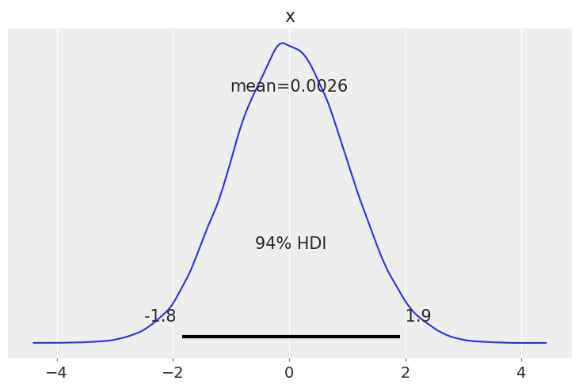

```julia
using Random

rng = Random.MersenneTwister(37772)
plot_posterior(randn(rng, 100_000));
gcf()
```

Plotting a dictionary of arrays, ArviZ.jl will interpret each key as the name of a different random variable. Each row of an array is treated as an independent series of draws from the variable, called a *chain*. Below, we have 10 chains of 50 draws each for four different distributions.

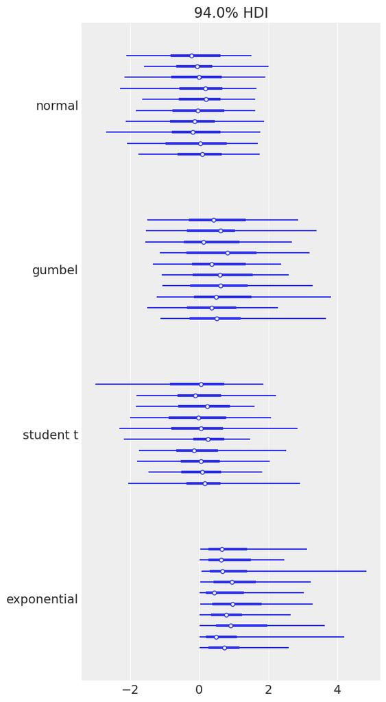

```julia
using Distributions

s = (10, 50)
plot_forest(
    Dict(
        "normal" => randn(rng, s),
        "gumbel" => rand(rng, Gumbel(), s),
        "student t" => rand(rng, TDist(6), s),
        "exponential" => rand(rng, Exponential(), s),
    ),
);
gcf()
```

## Plotting with MCMCChains.jl's `Chains` objects produced by Turing.jl

ArviZ is designed to work well with high dimensional, labelled data. Consider the [eight schools model](https://statmodeling.stat.columbia.edu/2014/01/21/everything-need-know-bayesian-statistics-learned-eight-schools/), which roughly tries to measure the effectiveness of SAT classes at eight different schools. To show off ArviZ's labelling, I give the schools the names of [a different eight schools](https://en.wikipedia.org/wiki/Eight_Schools_Association).

This model is small enough to write down, is hierarchical, and uses labelling. Additionally, a centered parameterization causes [divergences](https://mc-stan.org/users/documentation/case-studies/divergences_and_bias.html) (which are interesting for illustration).

First we create our data and set some sampling parameters.

```julia
J = 8
y = [28.0, 8.0, -3.0, 7.0, -1.0, 1.0, 18.0, 12.0]
σ = [15.0, 10.0, 16.0, 11.0, 9.0, 11.0, 10.0, 18.0]
schools = [
    "Choate",
    "Deerfield",
    "Phillips Andover",
    "Phillips Exeter",
    "Hotchkiss",
    "Lawrenceville",
    "St. Paul's",
    "Mt. Hermon",
];

nwarmup, nsamples, nchains = 1000, 1000, 4;
```

Now we write and run the model using Turing:

```julia
using Turing

Turing.@model function turing_model(y, σ, J=length(y))
    μ ~ Normal(0, 5)
    τ ~ truncated(Cauchy(0, 5), 0, Inf)
    θ ~ filldist(Normal(μ, τ), J)
    for i in 1:J
        y[i] ~ Normal(θ[i], σ[i])
    end
end

param_mod = turing_model(y, σ)
sampler = NUTS(nwarmup, 0.8)

rng = Random.MersenneTwister(16653)
turing_chns = sample(
    rng, param_mod, sampler, MCMCThreads(), nsamples, nchains; progress=false
);
```

```
┌ Info: Found initial step size
└   ϵ = 0.4
┌ Info: Found initial step size
└   ϵ = 0.8
┌ Info: Found initial step size
└   ϵ = 0.4
┌ Info: Found initial step size
└   ϵ = 0.8
```

Most ArviZ functions work fine with `Chains` objects from Turing:

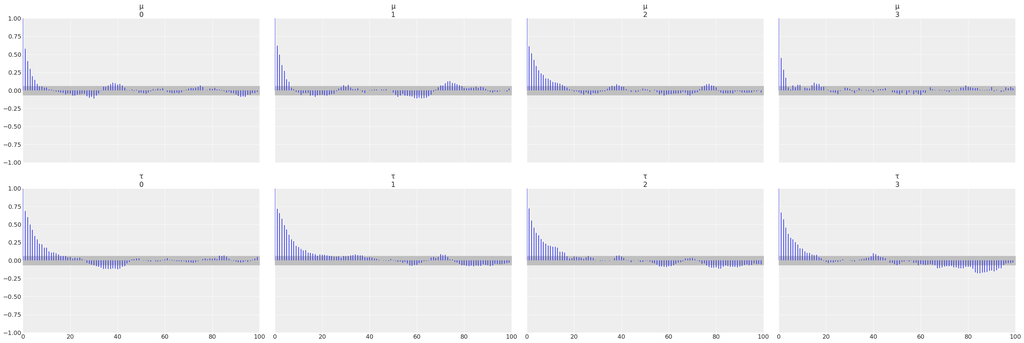

```julia
plot_autocorr(turing_chns; var_names=["μ", "τ"]);
gcf()
```

### Convert to `InferenceData`

For much more powerful querying, analysis and plotting, we can use built-in ArviZ utilities to convert `Chains` objects to xarray datasets. Note we are also giving some information about labelling.

ArviZ is built to work with `InferenceData` (a netcdf datastore that loads data into `xarray` datasets), and the more *groups* it has access to, the more powerful analyses it can perform.

```julia
idata = from_mcmcchains(
    turing_chns;
    coords=Dict("school" => schools),
    dims=Dict("y" => ["school"], "σ" => ["school"], "θ" => ["school"]),
    library="Turing",
)
```

InferenceData

- posterior

  ```
  Dataset (xarray.Dataset)
  Dimensions:  (chain: 4, draw: 1000, school: 8)
  Coordinates:
    * chain    (chain) int64 0 1 2 3
    * draw     (draw) int64 0 1 2 3 4 5 6 7 8 ... 992 993 994 995 996 997 998 999
    * school   (school) <U16 'Choate' 'Deerfield' ... "St. Paul's" 'Mt. Hermon'
  Data variables:
      μ        (chain, draw) float64 3.598 3.844 3.727 1.557 ... 3.421 3.421 3.421
      τ        (chain, draw) float64 1.341 1.253 0.9012 ... 0.6994 0.6994 0.6994
      θ        (chain, draw, school) float64 3.826 4.778 2.754 ... 4.154 3.907
  Attributes:
      created_at:         2021-04-22T20:52:40.248325
      arviz_version:      0.11.2
      inference_library:  Turing
  ```

- sample_stats

  ```
  Dataset (xarray.Dataset)
  Dimensions:           (chain: 4, draw: 1000)
  Coordinates:
    * chain             (chain) int64 0 1 2 3
    * draw              (draw) int64 0 1 2 3 4 5 6 ... 993 994 995 996 997 998 999
  Data variables:
      energy            (chain, draw) float64 49.74 48.67 52.26 ... 46.47 48.96
      energy_error      (chain, draw) float64 -0.1874 0.05797 0.1596 ... 0.0 0.0
      tree_depth        (chain, draw) float64 3.0 3.0 3.0 4.0 ... 2.0 1.0 2.0 3.0
      diverging         (chain, draw) bool False False False ... True False False
      step_size_nom     (chain, draw) float64 0.1222 0.1288 ... 0.1604 0.1604
      acceptance_rate   (chain, draw) float64 0.9568 0.9265 ... 0.008085 0.0001577
      log_density       (chain, draw) float64 -46.53 -46.78 ... -42.44 -42.44
      max_energy_error  (chain, draw) float64 -0.8297 0.1387 ... 544.5 803.6
      is_accept         (chain, draw) float64 1.0 1.0 1.0 1.0 ... 1.0 1.0 1.0 1.0
      lp                (chain, draw) float64 -46.53 -46.78 ... -42.44 -42.44
      step_size         (chain, draw) float64 0.1222 0.1288 ... 0.1604 0.1604
      n_steps           (chain, draw) float64 15.0 7.0 7.0 31.0 ... 2.0 3.0 7.0
  Attributes:
      created_at:         2021-04-22T20:52:40.278798
      arviz_version:      0.11.2
      inference_library:  Turing
  ```

Each group is an `ArviZ.Dataset` (a thinly wrapped `xarray.Dataset`). We can view a summary of the dataset.

```julia
idata.posterior
```

```
Dataset (xarray.Dataset)
Dimensions:  (chain: 4, draw: 1000, school: 8)
Coordinates:
  * chain    (chain) int64 0 1 2 3
  * draw     (draw) int64 0 1 2 3 4 5 6 7 8 ... 992 993 994 995 996 997 998 999
  * school   (school) <U16 'Choate' 'Deerfield' ... "St. Paul's" 'Mt. Hermon'
Data variables:
    μ        (chain, draw) float64 3.598 3.844 3.727 1.557 ... 3.421 3.421 3.421
    τ        (chain, draw) float64 1.341 1.253 0.9012 ... 0.6994 0.6994 0.6994
    θ        (chain, draw, school) float64 3.826 4.778 2.754 ... 4.154 3.907
Attributes:
    created_at:         2021-04-22T20:52:40.248325
    arviz_version:      0.11.2
    inference_library:  Turing
```

Here is a plot of the trace. Note the intelligent labels.

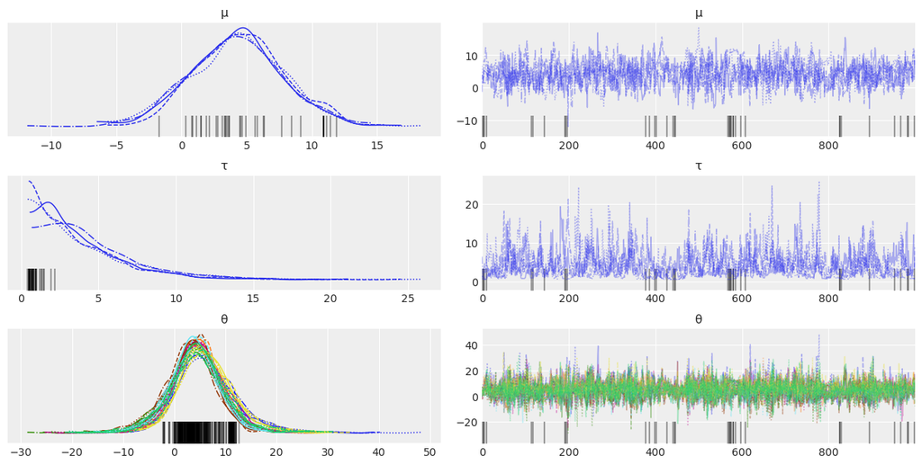

```julia
plot_trace(idata);
gcf()
```

We can also generate summary stats

```julia
summarystats(idata)
```

|  | variable String | mean Float64 | sd Float64 | hdi_3% Float64 | hdi_97% Float64 | mcse_mean Float64 | mcse_sd Float64 | ess_bulk Float64 | ess_tail Float64 | r_hat Float64 |
| --- | --- | --- | --- | --- | --- | --- | --- | --- | --- | --- |
| 1 | μ | 4.281 | 3.539 | -2.267 | 10.986 | 0.13 | 0.098 | 744.0 | 617.0 | 1.0 |
| 2 | τ | 4.01 | 3.163 | 0.407 | 9.728 | 0.172 | 0.122 | 195.0 | 191.0 | 1.02 |
| 3 | θ[1] | 6.368 | 5.964 | -4.518 | 17.567 | 0.187 | 0.135 | 1025.0 | 1630.0 | 1.0 |
| 4 | θ[2] | 4.949 | 4.868 | -4.257 | 14.151 | 0.143 | 0.101 | 1086.0 | 2160.0 | 1.0 |
| 5 | θ[3] | 3.806 | 5.586 | -7.338 | 13.475 | 0.157 | 0.114 | 1175.0 | 1570.0 | 1.0 |
| 6 | θ[4] | 4.592 | 5.079 | -4.53 | 14.542 | 0.153 | 0.114 | 1061.0 | 1672.0 | 1.0 |
| 7 | θ[5] | 3.362 | 4.921 | -6.809 | 11.889 | 0.142 | 0.106 | 1153.0 | 1659.0 | 1.0 |
| 8 | θ[6] | 3.896 | 5.028 | -5.593 | 13.604 | 0.15 | 0.109 | 1060.0 | 1543.0 | 1.0 |
| 9 | θ[7] | 6.48 | 5.359 | -2.887 | 17.167 | 0.176 | 0.124 | 916.0 | 1439.0 | 1.0 |
| 10 | θ[8] | 4.746 | 5.784 | -6.76 | 15.143 | 0.153 | 0.126 | 1245.0 | 1739.0 | 1.0 |

and examine the energy distribution of the Hamiltonian sampler

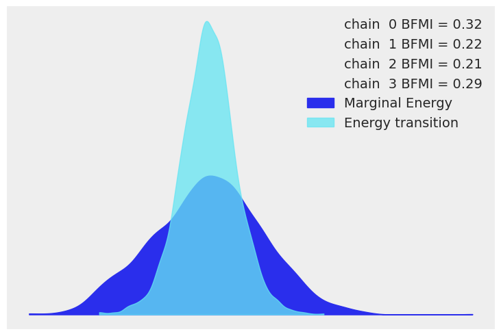

```julia
plot_energy(idata);
gcf()
```

### Additional information in Turing.jl

With a few more steps, we can use Turing to compute additional useful groups to add to the `InferenceData`.

To sample from the prior, one simply calls `sample` but with the `Prior` sampler:

```julia
prior = sample(param_mod, Prior(), nsamples; progress=false)
```

```
Chains MCMC chain (1000×11×1 Array{Float64, 3}):

Iterations        = 1:1000
Thinning interval = 1
Chains            = 1
Samples per chain = 1000
parameters        = θ[1], θ[2], θ[3], θ[4], θ[5], θ[6], θ[7], θ[8], μ, τ
internals         = lp

Summary Statistics
  parameters      mean       std   naive_se      mcse         ess      rhat
      Symbol   Float64   Float64    Float64   Float64     Float64   Float64

        θ[1]    0.9495   67.9183     2.1478    1.8926    556.5266    1.0001
        θ[2]   -0.6053   48.9281     1.5472    1.0120   1024.0944    1.0000
        θ[3]   -1.1761   60.8375     1.9238    1.5571    999.5217    0.9991
        θ[4]    0.1684   52.6024     1.6634    1.8087    811.6064    1.0025
        θ[5]    1.7505   71.2369     2.2527    2.2212    918.8990    0.9993
        θ[6]    2.0359   74.2804     2.3490    2.5844   1004.3982    1.0023
        θ[7]    1.1503   53.3496     1.6871    1.6193   1044.4259    0.9991
        θ[8]    0.7439   58.6209     1.8538    1.9887    965.1255    1.0011
           μ    0.0522    4.8552     0.1535    0.1401   1030.5527    1.0003
           τ   18.2545   68.3487     2.1614    2.4279    638.0227    0.9996

Quantiles
  parameters       2.5%     25.0%     50.0%     75.0%      97.5%
      Symbol    Float64   Float64   Float64   Float64    Float64

        θ[1]   -53.1021   -5.5494    0.0282    5.4924    42.0920
        θ[2]   -47.9095   -4.9937    0.2079    6.0771    38.2048
        θ[3]   -48.4412   -5.0144    0.3014    5.8416    39.0567
        θ[4]   -36.2510   -4.9584    0.4786    6.0296    46.7597
        θ[5]   -41.1661   -5.4494   -0.3680    5.0671    53.3500
        θ[6]   -40.9711   -5.4135    0.2481    5.6112    47.2051
        θ[7]   -39.5905   -5.2035    0.4159    6.4169    50.1237
        θ[8]   -49.2875   -4.9863    0.2812    5.8763    55.9611
           μ    -9.7057   -3.3349   -0.0951    3.3130     9.5634
           τ     0.1994    2.0832    4.9683   11.2756   112.9419
```

To draw from the prior and posterior predictive distributions we can instantiate a "predictive model", i.e. a Turing model but with the observations set to `missing`, and then calling `predict` on the predictive model and the previously drawn samples:

```julia
# Instantiate the predictive model
param_mod_predict = turing_model(similar(y, Missing), σ)
# and then sample!
prior_predictive = predict(param_mod_predict, prior)
posterior_predictive = predict(param_mod_predict, turing_chns)
```

```
Chains MCMC chain (1000×8×4 Array{Float64, 3}):

Iterations        = 1:1000
Thinning interval = 1
Chains            = 1, 2, 3, 4
Samples per chain = 1000
parameters        = y[1], y[2], y[3], y[4], y[5], y[6], y[7], y[8]
internals         =

Summary Statistics
  parameters      mean       std   naive_se      mcse         ess      rhat
      Symbol   Float64   Float64    Float64   Float64     Float64   Float64

        y[1]    6.7299   15.9314     0.2519    0.2656   3382.8938    0.9995
        y[2]    5.1808   11.0360     0.1745    0.2156   2715.1409    1.0001
        y[3]    3.8099   16.6724     0.2636    0.3024   3304.6641    0.9997
        y[4]    4.6548   12.1679     0.1924    0.1907   3199.7306    0.9992
        y[5]    3.4124   10.3672     0.1639    0.2069   2723.5195    1.0005
        y[6]    4.1893   12.0075     0.1899    0.2388   2634.5828    1.0016
        y[7]    6.5625   11.4302     0.1807    0.2177   2635.9058    1.0001
        y[8]    4.6207   18.9571     0.2997    0.3137   3849.2631    0.9994

Quantiles
  parameters       2.5%     25.0%     50.0%     75.0%     97.5%
      Symbol    Float64   Float64   Float64   Float64   Float64

        y[1]   -24.5533   -3.8211    6.8480   17.3388   37.5292
        y[2]   -16.4531   -2.3819    5.1510   12.7022   26.5208
        y[3]   -28.5546   -7.5131    3.9129   14.6435   37.3559
        y[4]   -19.1001   -3.6229    4.7003   12.8447   28.0479
        y[5]   -16.8125   -3.3436    3.3293   10.3243   24.0282
        y[6]   -19.0097   -3.7533    4.1301   12.3220   28.5534
        y[7]   -15.1607   -1.1611    6.6001   14.1673   28.5245
        y[8]   -32.1000   -8.1996    4.3825   17.2038   42.8640
```

And to extract the pointwise log-likelihoods, which is useful if you want to compute metrics such as `loo`,

```julia
loglikelihoods = Turing.pointwise_loglikelihoods(param_mod, turing_chns)
```

```
Dict{String, Matrix{Float64}} with 8 entries:
  "y[6]" => [-3.38973 -3.51189 -3.324 -3.33356; -3.32076 -3.32165 -3.31699 -3.3…
  "y[2]" => [-3.27342 -3.22381 -3.52234 -3.57384; -3.36404 -3.42648 -3.46043 -3…
  "y[1]" => [-4.92564 -4.6233 -5.2227 -4.96103; -4.94726 -5.12105 -5.21876 -5.0…
  "y[5]" => [-3.17195 -3.55913 -3.14524 -3.15421; -3.34779 -3.17499 -3.17355 -3…
  "y[8]" => [-3.92493 -3.82086 -4.01312 -4.05293; -3.9033 -3.92951 -4.0134 -3.9…
  "y[7]" => [-4.20172 -3.96703 -4.58952 -4.08009; -4.1926 -4.5937 -4.51744 -4.1…
  "y[3]" => [-3.75618 -3.87783 -3.74619 -3.74796; -3.80406 -3.74826 -3.71879 -3…
  "y[4]" => [-3.38347 -3.32362 -3.44944 -3.54315; -3.33491 -3.50791 -3.41815 -3…
```

This can then be included in the `from_mcmcchains` call from above:

```julia
using LinearAlgebra
# Ensure the ordering of the loglikelihoods matches the ordering of `posterior_predictive`
ynames = string.(keys(posterior_predictive))
loglikelihoods_vals = getindex.(Ref(loglikelihoods), ynames)
# Reshape into `(nchains, nsamples, size(y)...)`
loglikelihoods_arr = permutedims(cat(loglikelihoods_vals...; dims=3), (2, 1, 3))

idata = from_mcmcchains(
    turing_chns;
    posterior_predictive=posterior_predictive,
    log_likelihood=Dict("y" => loglikelihoods_arr),
    prior=prior,
    prior_predictive=prior_predictive,
    observed_data=Dict("y" => y),
    coords=Dict("school" => schools),
    dims=Dict("y" => ["school"], "σ" => ["school"], "θ" => ["school"]),
    library="Turing",
)
```

InferenceData

- posterior

  ```
  Dataset (xarray.Dataset)
  Dimensions:  (chain: 4, draw: 1000, school: 8)
  Coordinates:
    * chain    (chain) int64 0 1 2 3
    * draw     (draw) int64 0 1 2 3 4 5 6 7 8 ... 992 993 994 995 996 997 998 999
    * school   (school) <U16 'Choate' 'Deerfield' ... "St. Paul's" 'Mt. Hermon'
  Data variables:
      μ        (chain, draw) float64 3.598 3.844 3.727 1.557 ... 3.421 3.421 3.421
      τ        (chain, draw) float64 1.341 1.253 0.9012 ... 0.6994 0.6994 0.6994
      θ        (chain, draw, school) float64 3.826 4.778 2.754 ... 4.154 3.907
  Attributes:
      created_at:         2021-04-22T20:53:13.874685
      arviz_version:      0.11.2
      inference_library:  Turing
  ```

- posterior_predictive

  ```
  Dataset (xarray.Dataset)
  Dimensions:  (chain: 4, draw: 1000, school: 8)
  Coordinates:
    * chain    (chain) int64 0 1 2 3
    * draw     (draw) int64 0 1 2 3 4 5 6 7 8 ... 992 993 994 995 996 997 998 999
    * school   (school) <U16 'Choate' 'Deerfield' ... "St. Paul's" 'Mt. Hermon'
  Data variables:
      y        (chain, draw, school) float64 37.05 16.89 6.065 ... -0.008774 28.94
  Attributes:
      created_at:         2021-04-22T20:53:13.421849
      arviz_version:      0.11.2
      inference_library:  Turing
  ```

- log_likelihood

  ```
  Dataset (xarray.Dataset)
  Dimensions:  (chain: 4, draw: 1000, school: 8)
  Coordinates:
    * chain    (chain) int64 0 1 2 3
    * draw     (draw) int64 0 1 2 3 4 5 6 7 8 ... 992 993 994 995 996 997 998 999
    * school   (school) <U16 'Choate' 'Deerfield' ... "St. Paul's" 'Mt. Hermon'
  Data variables:
      y        (chain, draw, school) float64 -4.926 -3.273 -3.756 ... -4.18 -3.91
  Attributes:
      created_at:         2021-04-22T20:53:13.815954
      arviz_version:      0.11.2
      inference_library:  Turing
  ```

- sample_stats

  ```
  Dataset (xarray.Dataset)
  Dimensions:           (chain: 4, draw: 1000)
  Coordinates:
    * chain             (chain) int64 0 1 2 3
    * draw              (draw) int64 0 1 2 3 4 5 6 ... 993 994 995 996 997 998 999
  Data variables:
      energy            (chain, draw) float64 49.74 48.67 52.26 ... 46.47 48.96
      energy_error      (chain, draw) float64 -0.1874 0.05797 0.1596 ... 0.0 0.0
      tree_depth        (chain, draw) float64 3.0 3.0 3.0 4.0 ... 2.0 1.0 2.0 3.0
      diverging         (chain, draw) bool False False False ... True False False
      step_size_nom     (chain, draw) float64 0.1222 0.1288 ... 0.1604 0.1604
      acceptance_rate   (chain, draw) float64 0.9568 0.9265 ... 0.008085 0.0001577
      log_density       (chain, draw) float64 -46.53 -46.78 ... -42.44 -42.44
      max_energy_error  (chain, draw) float64 -0.8297 0.1387 ... 544.5 803.6
      is_accept         (chain, draw) float64 1.0 1.0 1.0 1.0 ... 1.0 1.0 1.0 1.0
      lp                (chain, draw) float64 -46.53 -46.78 ... -42.44 -42.44
      step_size         (chain, draw) float64 0.1222 0.1288 ... 0.1604 0.1604
      n_steps           (chain, draw) float64 15.0 7.0 7.0 31.0 ... 2.0 3.0 7.0
  Attributes:
      created_at:         2021-04-22T20:53:13.879026
      arviz_version:      0.11.2
      inference_library:  Turing
  ```

- prior

  ```
  Dataset (xarray.Dataset)
  Dimensions:  (chain: 1, draw: 1000, school: 8)
  Coordinates:
    * chain    (chain) int64 0
    * draw     (draw) int64 0 1 2 3 4 5 6 7 8 ... 992 993 994 995 996 997 998 999
    * school   (school) <U16 'Choate' 'Deerfield' ... "St. Paul's" 'Mt. Hermon'
  Data variables:
      μ        (chain, draw) float64 4.591 -3.59 7.95 ... -7.285 -2.541 -5.66
      τ        (chain, draw) float64 3.726 4.819 0.8977 ... 1.353 9.565 7.004
      θ        (chain, draw, school) float64 2.823 1.1 7.183 ... -2.011 -7.082
  Attributes:
      created_at:         2021-04-22T20:53:14.286923
      arviz_version:      0.11.2
      inference_library:  Turing
  ```

- prior_predictive

  ```
  Dataset (xarray.Dataset)
  Dimensions:  (chain: 1, draw: 1000, school: 8)
  Coordinates:
    * chain    (chain) int64 0
    * draw     (draw) int64 0 1 2 3 4 5 6 7 8 ... 992 993 994 995 996 997 998 999
    * school   (school) <U16 'Choate' 'Deerfield' ... "St. Paul's" 'Mt. Hermon'
  Data variables:
      y        (chain, draw, school) float64 -19.08 -8.769 22.26 ... 15.77 -8.977
  Attributes:
      created_at:         2021-04-22T20:53:14.176878
      arviz_version:      0.11.2
      inference_library:  Turing
  ```

- sample_stats_prior

  ```
  Dataset (xarray.Dataset)
  Dimensions:  (chain: 1, draw: 1000)
  Coordinates:
    * chain    (chain) int64 0
    * draw     (draw) int64 0 1 2 3 4 5 6 7 8 ... 992 993 994 995 996 997 998 999
  Data variables:
      lp       (chain, draw) float64 -55.65 -65.73 -43.9 ... -55.26 -71.98 -66.78
  Attributes:
      created_at:         2021-04-22T20:53:14.313381
      arviz_version:      0.11.2
      inference_library:  Turing
  ```

- observed_data

  ```
  Dataset (xarray.Dataset)
  Dimensions:  (school: 8)
  Coordinates:
    * school   (school) <U16 'Choate' 'Deerfield' ... "St. Paul's" 'Mt. Hermon'
  Data variables:
      y        (school) float64 28.0 8.0 -3.0 7.0 -1.0 1.0 18.0 12.0
  Attributes:
      created_at:         2021-04-22T20:53:15.220348
      arviz_version:      0.11.2
      inference_library:  Turing
  ```

Then we can for example compute the expected *leave-one-out (LOO)* predictive density, which is an estimate of the out-of-distribution predictive fit of the model:

```julia
loo(idata) # higher is better
```

|  | loo Float64 | loo_se Float64 | p_loo Float64 | n_samples Int64 | n_data_points Int64 | warning Bool | loo_scale String |
| --- | --- | --- | --- | --- | --- | --- | --- |
| 1 | -30.8011 | 1.3667 | 0.963052 | 4000 | 8 | 0 | log |

If the model is well-calibrated, i.e. it replicates the true generative process well, the CDF of the pointwise LOO values should be similarly distributed to a uniform distribution. This can be inspected visually:

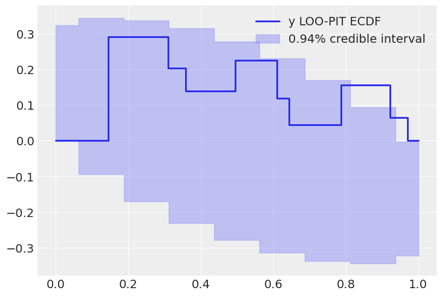

```julia
plot_loo_pit(idata; y="y", ecdf=true);
gcf()
```

## Plotting with CmdStan.jl outputs

CmdStan.jl and StanSample.jl also default to producing `Chains` outputs, and we can easily plot these chains.

Here is the same centered eight schools model:

```julia
using CmdStan, MCMCChains

schools_code = """
data {
  int<lower=0> J;
  real y[J];
  real<lower=0> sigma[J];
}

parameters {
  real mu;
  real<lower=0> tau;
  real theta[J];
}

model {
  mu ~ normal(0, 5);
  tau ~ cauchy(0, 5);
  theta ~ normal(mu, tau);
  y ~ normal(theta, sigma);
}

generated quantities {
    vector[J] log_lik;
    vector[J] y_hat;
    for (j in 1:J) {
        log_lik[j] = normal_lpdf(y[j] | theta[j], sigma[j]);
        y_hat[j] = normal_rng(theta[j], sigma[j]);
    }
}
"""

schools_dat = Dict("J" => J, "y" => y, "sigma" => σ)
stan_model = Stanmodel(;
    model=schools_code,
    name="schools",
    nchains=nchains,
    num_warmup=nwarmup,
    num_samples=nsamples,
    output_format=:mcmcchains,
    random=CmdStan.Random(28983),
)
_, stan_chns, _ = stan(stan_model, schools_dat; summary=false);
```

```
File /home/runner/work/ArviZ.jl/ArviZ.jl/docs/build/tmp/schools.stan will be updated.
```

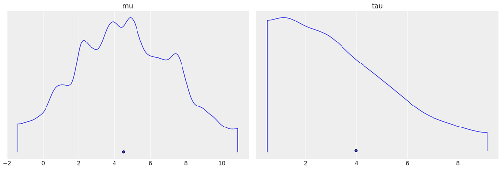

```julia
plot_density(stan_chns; var_names=["mu", "tau"]);
gcf()
```

Again, converting to `InferenceData`, we can get much richer labelling and mixing of data. Note that we're using the same `from_cmdstan` function used by ArviZ to process cmdstan output files, but through the power of dispatch in Julia, if we pass a `Chains` object, it instead uses ArviZ.jl's overloads, which forward to `from_mcmcchains`.

```julia
idata = from_cmdstan(
    stan_chns;
    posterior_predictive="y_hat",
    observed_data=Dict("y" => schools_dat["y"]),
    log_likelihood="log_lik",
    coords=Dict("school" => schools),
    dims=Dict(
        "y" => ["school"],
        "sigma" => ["school"],
        "theta" => ["school"],
        "log_lik" => ["school"],
        "y_hat" => ["school"],
    ),
)
```

InferenceData

- posterior

  ```
  Dataset (xarray.Dataset)
  Dimensions:  (chain: 4, draw: 1000, school: 8)
  Coordinates:
    * chain    (chain) int64 0 1 2 3
    * draw     (draw) int64 0 1 2 3 4 5 6 7 8 ... 992 993 994 995 996 997 998 999
    * school   (school) <U16 'Choate' 'Deerfield' ... "St. Paul's" 'Mt. Hermon'
  Data variables:
      theta    (chain, draw, school) float64 6.541 4.165 1.673 ... 7.588 7.146
      tau      (chain, draw) float64 2.026 3.44 2.047 ... 0.5002 0.5771 0.5771
      mu       (chain, draw) float64 5.864 4.849 3.906 5.24 ... 7.369 7.617 7.617
  Attributes:
      created_at:         2021-04-22T20:53:46.969205
      arviz_version:      0.11.2
      inference_library:  CmdStan
  ```

- posterior_predictive

  ```
  Dataset (xarray.Dataset)
  Dimensions:  (chain: 4, draw: 1000, school: 8)
  Coordinates:
    * chain    (chain) int64 0 1 2 3
    * draw     (draw) int64 0 1 2 3 4 5 6 7 8 ... 992 993 994 995 996 997 998 999
    * school   (school) <U16 'Choate' 'Deerfield' ... "St. Paul's" 'Mt. Hermon'
  Data variables:
      y_hat    (chain, draw, school) float64 -10.71 23.66 -9.425 ... 9.078 20.88
  Attributes:
      created_at:         2021-04-22T20:53:46.941372
      arviz_version:      0.11.2
      inference_library:  CmdStan
  ```

- log_likelihood

  ```
  Dataset (xarray.Dataset)
  Dimensions:  (chain: 4, draw: 1000, school: 8)
  Coordinates:
    * chain    (chain) int64 0 1 2 3
    * draw     (draw) int64 0 1 2 3 4 5 6 7 8 ... 992 993 994 995 996 997 998 999
    * school   (school) <U16 'Choate' 'Deerfield' ... "St. Paul's" 'Mt. Hermon'
  Data variables:
      log_lik  (chain, draw, school) float64 -4.65 -3.295 -3.734 ... -3.764 -3.846
  Attributes:
      created_at:         2021-04-22T20:53:46.950224
      arviz_version:      0.11.2
      inference_library:  CmdStan
  ```

- sample_stats

  ```
  Dataset (xarray.Dataset)
  Dimensions:          (chain: 4, draw: 1000)
  Coordinates:
    * chain            (chain) int64 0 1 2 3
    * draw             (draw) int64 0 1 2 3 4 5 6 ... 993 994 995 996 997 998 999
  Data variables:
      tree_depth       (chain, draw) float64 4.0 2.0 4.0 3.0 ... 1.0 5.0 3.0 2.0
      diverging        (chain, draw) bool False False False ... False True False
      energy           (chain, draw) float64 21.85 17.36 18.12 ... 11.01 16.54
      lp               (chain, draw) float64 -11.6 -14.53 -12.58 ... -6.09 -6.09
      step_size        (chain, draw) float64 0.2012 0.2012 ... 0.1493 0.1493
      acceptance_rate  (chain, draw) float64 0.9582 0.8976 ... 0.04874 1.587e-05
      n_steps          (chain, draw) float64 15.0 7.0 15.0 15.0 ... 31.0 9.0 3.0
  Attributes:
      created_at:         2021-04-22T20:53:46.980772
      arviz_version:      0.11.2
      inference_library:  CmdStan
  ```

- observed_data

  ```
  Dataset (xarray.Dataset)
  Dimensions:  (school: 8)
  Coordinates:
    * school   (school) <U16 'Choate' 'Deerfield' ... "St. Paul's" 'Mt. Hermon'
  Data variables:
      y        (school) float64 28.0 8.0 -3.0 7.0 -1.0 1.0 18.0 12.0
  Attributes:
      created_at:         2021-04-22T20:53:47.016394
      arviz_version:      0.11.2
      inference_library:  CmdStan
  ```

Here is a plot showing where the Hamiltonian sampler had divergences:

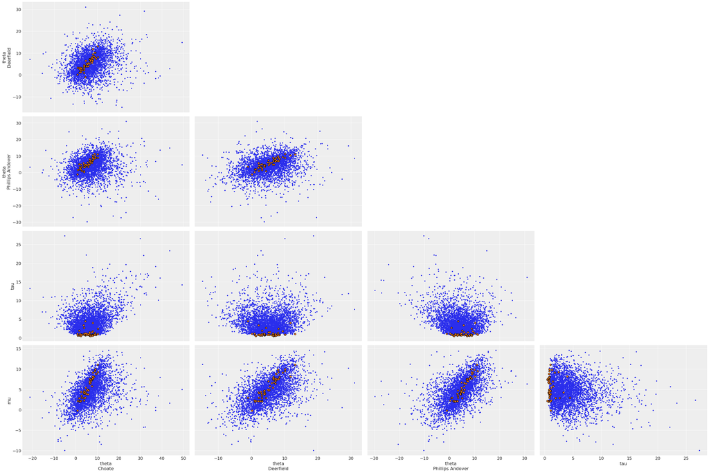

```julia
plot_pair(
    idata;
    coords=Dict("school" => ["Choate", "Deerfield", "Phillips Andover"]),
    divergences=true,
);
gcf()
```

## Plotting with Soss.jl outputs

With Soss, we can define our model for the posterior and easily use it to draw samples from the prior, prior predictive, posterior, and posterior predictive distributions.

First we define our model:

```julia
using Soss, NamedTupleTools

mod = Soss.@model (J, σ) begin
    μ ~ Normal(0, 5)
    τ ~ HalfCauchy(5)
    θ ~ iid(J)(Normal(μ, τ))
    y ~ For(1:J) do j
        Normal(θ[j], σ[j])
    end
end

constant_data = (J=J, σ=σ)
param_mod = mod(; constant_data...)
```

```
Joint Distribution
    Bound arguments: [J, σ]
    Variables: [τ, μ, θ, y]

@model (J, σ) begin
        τ ~ HalfCauchy(5)
        μ ~ Normal(0, 5)
        θ ~ (iid(J))(Normal(μ, τ))
        y ~ For(1:J) do j
                Normal(θ[j], σ[j])
            end
    end
```

Then we draw from the prior and prior predictive distributions.

```julia
Random.seed!(5298)
prior_priorpred = [
    map(1:(nchains * nsamples)) do _
        draw = rand(param_mod)
        return delete(draw, keys(constant_data))
    end,
];
```

Next, we draw from the posterior using DynamicHMC.jl.

```julia
post = map(1:nchains) do _
    dynamicHMC(param_mod, (y=y,), nsamples)
end;
```

Finally, we update the posterior samples with draws from the posterior predictive distribution.

```julia
pred = predictive(mod, :μ, :τ, :θ)
post_postpred = map(post) do post_draws
    map(post_draws) do post_draw
        pred_draw = rand(pred(post_draw))
        pred_draw = delete(pred_draw, keys(constant_data))
        return merge(pred_draw, post_draw)
    end
end;
```

Each Soss draw is a `NamedTuple`. We can plot the rank order statistics of the posterior to identify poor convergence:

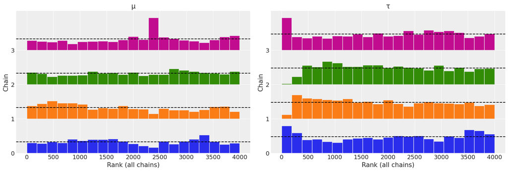

```julia
plot_rank(post; var_names=["μ", "τ"]);
gcf()
```

Now we combine all of the samples to an `InferenceData`:

```julia
idata = from_namedtuple(
    post_postpred;
    posterior_predictive=[:y],
    prior=prior_priorpred,
    prior_predictive=[:y],
    observed_data=(y=y,),
    constant_data=constant_data,
    coords=Dict("school" => schools),
    dims=Dict("y" => ["school"], "σ" => ["school"], "θ" => ["school"]),
    library=Soss,
)
```

InferenceData

- posterior

  ```
  Dataset (xarray.Dataset)
  Dimensions:  (chain: 4, draw: 1000, school: 8)
  Coordinates:
    * chain    (chain) int64 0 1 2 3
    * draw     (draw) int64 0 1 2 3 4 5 6 7 8 ... 992 993 994 995 996 997 998 999
    * school   (school) <U16 'Choate' 'Deerfield' ... "St. Paul's" 'Mt. Hermon'
  Data variables:
      μ        (chain, draw) float64 6.132 -0.1432 12.41 ... 4.982 4.982 4.982
      τ        (chain, draw) float64 6.015 7.961 8.634 6.549 ... 0.608 0.608 0.608
      θ        (chain, draw, school) float64 10.9 9.621 5.99 ... 5.301 4.064 4.779
  Attributes:
      created_at:         2021-04-22T20:54:40.764835
      arviz_version:      0.11.2
      inference_library:  Soss
  ```

- posterior_predictive

  ```
  Dataset (xarray.Dataset)
  Dimensions:  (chain: 4, draw: 1000, school: 8)
  Coordinates:
    * chain    (chain) int64 0 1 2 3
    * draw     (draw) int64 0 1 2 3 4 5 6 7 8 ... 992 993 994 995 996 997 998 999
    * school   (school) <U16 'Choate' 'Deerfield' ... "St. Paul's" 'Mt. Hermon'
  Data variables:
      y        (chain, draw, school) float64 3.218 13.51 -4.019 ... -2.613 4.718
  Attributes:
      created_at:         2021-04-22T20:54:40.762537
      arviz_version:      0.11.2
      inference_library:  Soss
  ```

- prior

  ```
  Dataset (xarray.Dataset)
  Dimensions:  (chain: 1, draw: 4000, school: 8)
  Coordinates:
    * chain    (chain) int64 0
    * draw     (draw) int64 0 1 2 3 4 5 6 7 ... 3993 3994 3995 3996 3997 3998 3999
    * school   (school) <U16 'Choate' 'Deerfield' ... "St. Paul's" 'Mt. Hermon'
  Data variables:
      μ        (chain, draw) float64 -1.058 6.136 -0.3852 ... 1.484 -10.82 -0.7505
      τ        (chain, draw) float64 149.7 0.02342 3.398 ... 4.347 84.28 4.543
      θ        (chain, draw, school) float64 -8.511 154.9 44.86 ... -2.911 -6.732
  Attributes:
      created_at:         2021-04-22T20:54:41.790388
      arviz_version:      0.11.2
      inference_library:  Soss
  ```

- prior_predictive

  ```
  Dataset (xarray.Dataset)
  Dimensions:  (chain: 1, draw: 4000, school: 8)
  Coordinates:
    * chain    (chain) int64 0
    * draw     (draw) int64 0 1 2 3 4 5 6 7 ... 3993 3994 3995 3996 3997 3998 3999
    * school   (school) <U16 'Choate' 'Deerfield' ... "St. Paul's" 'Mt. Hermon'
  Data variables:
      y        (chain, draw, school) float64 -19.44 137.9 18.57 ... 5.947 13.3
  Attributes:
      created_at:         2021-04-22T20:54:41.788131
      arviz_version:      0.11.2
      inference_library:  Soss
  ```

- observed_data

  ```
  Dataset (xarray.Dataset)
  Dimensions:  (school: 8)
  Coordinates:
    * school   (school) <U16 'Choate' 'Deerfield' ... "St. Paul's" 'Mt. Hermon'
  Data variables:
      y        (school) float64 28.0 8.0 -3.0 7.0 -1.0 1.0 18.0 12.0
  Attributes:
      created_at:         2021-04-22T20:54:42.303595
      arviz_version:      0.11.2
      inference_library:  Soss
  ```

- constant_data

  ```
  Dataset (xarray.Dataset)
  Dimensions:  (J_dim_0: 1, school: 8)
  Coordinates:
    * J_dim_0  (J_dim_0) int64 0
    * school   (school) <U16 'Choate' 'Deerfield' ... "St. Paul's" 'Mt. Hermon'
  Data variables:
      J        (J_dim_0) int64 8
      σ        (school) float64 15.0 10.0 16.0 11.0 9.0 11.0 10.0 18.0
  Attributes:
      created_at:         2021-04-22T20:54:43.634574
      arviz_version:      0.11.2
      inference_library:  Soss
  ```

We can compare the prior and posterior predictive distributions:

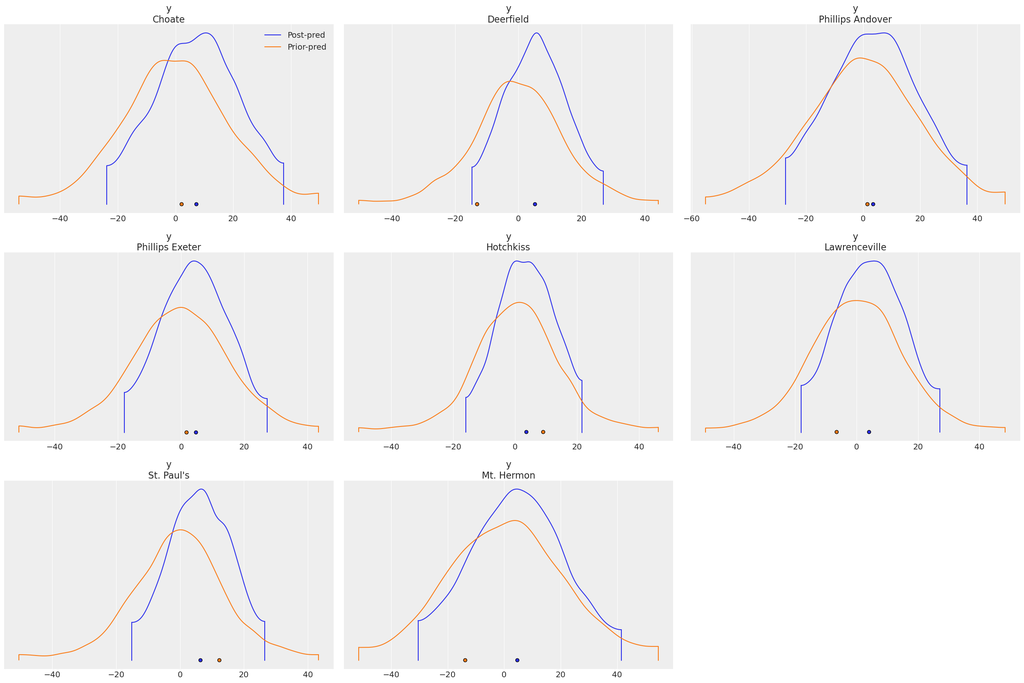

```julia
plot_density(
    [idata.posterior_predictive, idata.prior_predictive];
    data_labels=["Post-pred", "Prior-pred"],
    var_names=["y"],
)
gcf()
```

## Environment

```julia
using Pkg
Pkg.status()
```

```
      Status `~/work/ArviZ.jl/ArviZ.jl/docs/Project.toml`
  [131c737c] ArviZ v0.5.0 `~/work/ArviZ.jl/ArviZ.jl`
  [593b3428] CmdStan v6.1.10
  [31c24e10] Distributions v0.23.8
  [e30172f5] Documenter v0.26.3
  [366bfd00] DynamicPPL v0.10.8
  [c7f686f2] MCMCChains v4.8.0
  [d9ec5142] NamedTupleTools v0.13.7
  [438e738f] PyCall v1.92.3
  [d330b81b] PyPlot v2.9.0
  [8ce77f84] Soss v0.14.4
  [fce5fe82] Turing v0.15.15
  [37e2e46d] LinearAlgebra
```

```julia
using InteractiveUtils
versioninfo()
```

```
Julia Version 1.6.0
Commit f9720dc2eb (2021-03-24 12:55 UTC)
Platform Info:
  OS: Linux (x86_64-pc-linux-gnu)
  CPU: Intel(R) Xeon(R) Platinum 8272CL CPU @ 2.60GHz
  WORD_SIZE: 64
  LIBM: libopenlibm
  LLVM: libLLVM-11.0.1 (ORCJIT, skylake-avx512)
Environment:
  JULIA_CMDSTAN_HOME = /home/runner/work/ArviZ.jl/ArviZ.jl/.cmdstan//cmdstan-2.25.0/
  JULIA_NUM_THREADS = 2
```